# Estimation of the number of tree species in French Guiana by extrapolation of permanent plots richness

Eric Marcon , Ariane Mirabel , Jean-François Molino , Daniel Sabatier  
2022 September 08

# 1 Introduction

Biodiversity assessment in tropical moist forests is a practical challenge but a major goal considering they are the most diverse terrestrial ecosystems. Estimating the number of tree species is made possible by the long-term effort of sampling resulting in thousands of forest plots organized in various networks. In French Guiana, the GuyaDiv network consists of close to 250 plots across the whole forest. Based on similar datasets, the diversity of tree species has been estimated in Amazonia (ter Steege *et al.* 2013; ter Steege *et al.* 2020) and at the world scale (Slik *et al.* 2015). The methods used in those studies are not appropriate to estimate regional diversity, i.e. at a smaller scale where dispersal limitation is critical. The contribution of this paper is to estimate the number of tree species at the regional scale, in French Guiana (8 million hectares of tropical moist forest with no ecological boundary to distinguish them from the rest of Amazonia) and demonstrate which method is valid to do so. We build on Harte’s self similarity model (Harte *et al.* 1999a) that implies the power-law relationship of Arrhenius (1921) and provides a technique to evaluate its parameters (Harte *et al.* 1999b), previously applied by Krishnamani *et al.* (2004) in the Western Ghats, India, a 60,000-ha tropical forest with around 1,000 species. We show that the log-series model underlying the work of ter Steege *et al.* (2013) does not apply at the regional scale. We also compare our results to those obtained by alternative methods such as the MaxEnt species-area curve (Harte *et al.* 2009) and the grid-aggregated occurrence-based estimation by Cazzolla Gatti *et al.* (2022).

# 2 Methods

Self-similarity (Harte *et al.* 1999a) is a property based on scale invariance. Consider a species that is present in an area $A_0$, say French Guiana. The probability to find it in half the whole area, denoted $A_1$ is $a$. Then, if it is present $A_1$, the probability to find it in turn in half $A_1$, denoted $A_2$, is also $a$, and so on. The probability to find the species in $A_n$ is thus $a^n$. In other words, the conditional probability to find a species in a sub-area, given that it is present in the area containing it, is constant: it does not depend either on the observation scale nor the species considered.

The Arrhenius power law (Arrhenius 1921) both implies and is a consequence of the self-similarity property (Harte *et al.* 1999a). The number of species $\mathrm{S}(A)$ observed in an area $A$ is

$$\begin{equation}
\mathrm{S}(A)=cA^z
\tag{1}
\end{equation}$$

where $z$ is the power parameter and $c$ is the number of species in an area of size 1. Actually, $a=2^{-z}$. This is a classical relation in macroecology, with long empirical and theoretical support (Gárcia Martín & Goldenfeld 2006; Williamson *et al.* 2001).

If $z$ is known, the inventory of a reasonably large area $b$ allows computing $c=S(b)/b^{z}$. Then, $\mathrm{S}(A)$ can be calculated for any value of $A$.

Harte *et al.* (1999b) showed that under the assumption of self-similarity, $z$ can be inferred from the dissimilarity between small and distant plots of equal size distributed across the area. The Sørensen (1948) similarity between two plots is

$$\begin{equation}
\chi = 2 (S_1 \cap S_2) / (S_1 + S_2)
\tag{2}
\end{equation}$$

where $S_1$ (respectively $S_2$) is the number of species in plot 1 (resp. plot 2) and $S_1 \cap S_2$ is the number of common species.

Applied to plots of the same size separated by distance $d$, Sørensen’s similarity decreases with distance following the relation $\chi \sim d^{-2z}$ (Harte *et al.* 1999b) that can be estimated by the linear model

$$\begin{equation}
\log(\chi) \sim \log(d).
\tag{3}
\end{equation}$$

The logarithm of the Sørensen dissimilarity between pairs of plots can be regressed against the logarithm of the distance between the plots: the slope of the regression is $-2z$.

The relation (3) holds at the same scale as the power law, i.e. at the regional scale (Grilli *et al.* 2012). Krishnamani *et al.* (2004) estimated $z \approx 0.12$ with a very good fit to the linear model at distances up from 1 km but not below.

A large enough inventory, provided by a permanent forest facility, is necessary along with a set of small, widely spread forest plots. Our plot network is GuyaDiv (Engel 2015). Since the installation of the first plots in 1986, the GuyaDiv network has continuously grown until today. It now consists of 243 plots of various sizes and shapes, distributed in various forest types, in 30 sites across French Guiana (figure 1). We took into account the 68 one-hectare plots of the network. They are located in 21 sites, which provides fairly good coverage of the variability of the forest in French Guiana.

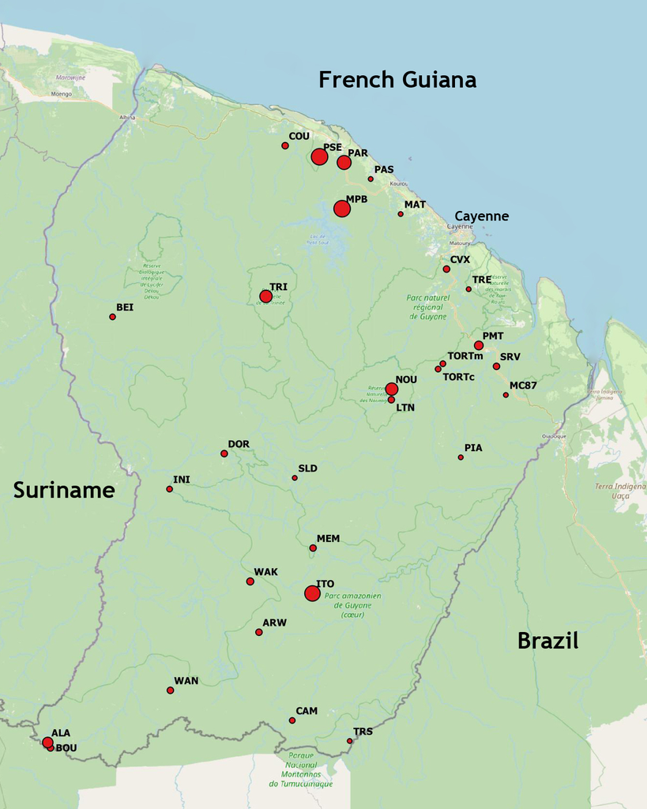

Figure 1: The GuyaDiv network. Paracou, Piste de Saint-Elie and Nouragues are denoted PAR, PSE and NOU.

We gathered 3 local, large inventories to account for environmental variability and a network of plot covering the whole region.

The Paracou research station (Gourlet-Fleury *et al.* 2004) contains six 6.25-ha and one 25-ha plots of primary rainforest. Nine 6.25-ha plots were logged between 1986 and 1988 in a forestry experiment that temporarily increased the recruitment of light-demanding species (Mirabel *et al.* 2021) and the functional diversity (Mirabel *et al.* 2020).

In a rather conservative approach, we retained only the well-identified trees of the permanent plots (571 species) and added available data from the GuyaDiv network: transects from Molino & Sabatier (2001) and ten 0.49-ha plots around the Guyaflux tower (Bonal *et al.* 2008) contain 575 species, including 132 new ones. 37 more species at the French Guiana IRD Herbarium (CAY: Gonzalez *et al.* 2022) were collected in the area but outside the plots. The total number of species is thus 740 included in a 4.84-km<sup>2</sup> convex envelope.

The Piste de Saint-Elie site has been intensively sampled for 50 years. It encompasses nineteen 1-ha and one half-hectare plots in GuyaDiv and a few small plots added for various studies. Moreover, many herbarium specimen were collected from the site. As a whole, we gathered 763 species in a 3-km<sup>2</sup> area.

Nouragues research station (Bongers *et al.* 2001) provides 22 hectares of permanent plots. We applied the same protocol, adding 11 Guyadiv plots and herbarium collections up to 850 species in a 2.5-km<sup>2</sup> area.

The number of plots varies across locations so the estimation of $z$ must be made with care. We sampled one random plot at each location to obtain $21 \times 20/2 = 210$ pairs of plots. We calculated the Sørensen dissimilarity $\chi$ and the geographic distance $d$ between each pair of plots. We estimated $z$ as half the coefficient of the distance variable in the linear model $\log(\chi) \sim \log(d)$. We repeated these steps 1000 times to obtain a distribution of estimated $z$ values depending on the plots drawn in each location. $z$ was estimated as the empirical mean of the distribution and its 95% confidence interval was obtained by eliminating the 2.5% extreme values on both tails.

The confidence interval of the estimation of the number of species is assessed by combining the uncertainty in $c$ and $A^z$. The variance of $c$ is estimated from the three observed values. That of $A^z$ is obtained from the empirical distribution of $z$. The variance of their product is calculated (the formula and its derivation are in Appendix 5.2). Finally, we assumed the normality of the distribution of the product of the estimates to retain an approximate 95% confidence interval of $\pm$ 2 standard deviations.

All analyses were made with R (R Core Team 2022) v. 4.1.3.

# 3 Results

The estimated value of $z$ is 0.103 with a 95% confidence interval between 0.089 and 0.121.

The estimated number of species per squared kilometer, $c$, is respectively 629, 681 and 773 in Paracou, Piste de Saint-Elie and Nouragues. The average value is 694.

Finally, the estimated number of species is 2230. Taking into account the uncertainty about $z$, its 95% confidence interval is between 1589 and 2872.

# 4 Discussion

The self-similarity model allows estimating the number of species of tropical forests at a regional scale. It requires a network of plots at a wide range of distances from each other to estimate Arrhenius’s power law parameter. It should be completed by a continuous inventory whose size is consistent with the smallest scale of the power law. These constraints explain why the method has not been widely applied, beyond Krishnamani *et al.* (2004) and this paper.

At smaller scales, i.e. inside a single community, the relation between area and number of species is described by species accumulation curves (SAC: Gotelli & Colwell 2001). It is driven by statistical models that address incomplete sampling (Béguinot 2015; Shen *et al.* 2003). After replacing the sampled area by the number of individuals it contains, well-known estimators of richness such as Chao’s (Chao 2004) or the jackknife (Burnham & Overton 1978) apply. This estimation is in appendix 5.3. It is less than 1700 species, i.e. less than the total number of known species (Molino *et al.* 2022). As already underlined by ter Steege *et al.* (2013), this method is not appropriate at large scales because of severe undersampling: many local communities are just not included in the data.

Cazzolla Gatti *et al.* (2022) applied a similar method on a large-scale grid (100 x 100 km cells) where species occurrences were reported in each cell. Considering each cell as a plot, the Chao2 estimator (Chao 1987) allows estimating the total richness. The advantage of this approach is the opportunity to combine several sources of occurrence data to improve the sampling coverage. When applied to our data, aggregated in 100-km square cells (appendix 5.3), the estimation is similar to that obtained directly from the abundance data of the plots.

At the scale of the metacommunity, defined as of the neutral model of biogeography, the species distribution is in log-series (Hubbell 2001; Volkov *et al.* 2003). ter Steege *et al.* (2013) fitted a log-series to data provided by a network of plots to estimate the number of species in Amazonia. We applied the same method to our data in appendix 5.4. Its estimation is well over 4000 species in French Guiana: a very unlikely result according to the current expert knowledge and the recent checklist (Molino *et al.* 2022). The regional species pool does not follow a log-series distribution because of dispersal limitation (Grilli *et al.* 2012). In other words, the regional community is not a sample of the metacommunity: many of the metacommunity’s species are not present. As a consequence, the log-series estimation of the richness of a regional species pool leads to severe overestimation. For the same reasons, hyperdominance is less pronounced: 4% of the species contain half the trees (appendix 5.5), compared to 1.4% in Amazonia as a whole (ter Steege *et al.* 2013).

Harte *et al.* (2008) derived a universal species-area relationship based on the maximum entropy theory. Assuming only that the area, the total numbers of species and individuals, and the summed metabolic energy rate of all individuals are fixed, many features of the species distribution at any scale can be predicted. Of particular interest is the possibility to derive the number of species in a doubled area from the number of species in a sampled, reference area (Harte *et al.* 2009; Xu *et al.* 2012). Starting from a local sample, that may be a single 1-ha plot or one of our large inventories, the area can be doubled until the target size is reached. The number of species estimated from Paracou, Piste de Saint-Elie and Nouragues starting points (their number of species and area) is on average close to 2800, and over 3000 when extrapolating from an average Guyadiv 1-ha plot (appendix 5.6). Again, this model implies a log-series distribution as it integrates as few assumptions as possible (Harte *et al.* 2008). The arguments for overestimation are the same as those against the extrapolation of the log-series at the regional scale.

As shown in figure 2, the fit of the linear model is not perfect. The theory does not address habitat variation, that is well-described in French Guiana (Guitet *et al.* 2015). The dissimilarity between plot pairs is thus explained by distance and habitat dissimilarity, the latter ignored in the model. Yet, the estimation of $z$ is quite robust because the GuyaDiv network covers a wide range of habitats, allowing to cancel out local variability. Adding more plots or describing a few more species in the previous plots may not change $z$ significantly since it is obtained from the dissimilarity between plots. Its value 0.103 is in line with that of Krishnamani *et al.* (2004) in another tropical forest: it is very small compared to the classical 0.25 of Arrhenius (1921) or 0.263 of Preston (1962). This was discussed by MacArthur & Wilson (1967), chapter 2. The power law applies to embedded scales of the same ecosystem here, in contrast to the usual sets of isolated islands providing the data (Triantis *et al.* 2012): in our case, the number of species increases less with the area, leading to smaller $z$ values.

The critical aspect of the estimation is the accuracy of the starting point of the extrapolation, that mainly depends on the representativeness of the local inventories Again, the self-similarity model assumes that $c$, the number of species per squared kilometer, is the same everywhere. Local, observed values must be understood as variations around the real $c$, that should be estimated by replicating inventories across the whole region. This is of course restricted by the huge resources needed to settle a single one: three replicates are an exceptional amount of data. Paracou, Piste de Saint-Elie and Nouragues represent quite well the variability of local richness of the forest of French Guiana. We made a strict selection of the data to count the numbers of species, which are thus lower bounds. Ongoing efforts of botanists may increase a bit the value of $c$, implying a proportional increase in the estimation of the number of species.

A recent work (Molino *et al.* 2022) lists nearly 1800 species of indigenous trees in French Guiana, based on herbarium collections on the one hand, and on data from the GuyaDiv and GuyaFor plot networks (Engel 2015) on the other. However, this checklist is only a state of the art of our knowledge of the tree flora. Even in the most intensively explored areas, botanists conducting botanical inventories have identified a number of entities that are morphologically distinct from all known species in French Guiana, and which they therefore consider to be still unnamed species. They gave them provisional names (e.g. *Pouteria* sp. A), until more information is available to either recognize species known in other parts of the world, or to describe them and give them a valid name according to the Code of Nomenclature. The GuyaDiv and GuyaFor databases together currently list more than 300 of these unnamed species, but Molino *et al.* (2022) selected only 144 of them for their checklist, the ones that were best characterized and best illustrated by good quality herbarium specimens. Although it cannot be excluded that some of the other 150-200 unnamed species are in fact simple morphological variants of already described species, they believe that most of them represent distinct species. In other words, the number of known species in French Guiana (named and unnamed) is probably already close to 2000. Furthermore, the available data is very unevenly distributed across the territory. The south and especially the north-west of French Guiana are poorly explored botanically (few inventory plots, relatively few herbarium specimens), while their floras are significantly different from the better inventoried northern and central zones. It is thus very likely that the exploration of these little-known areas will add new species to the list. Therefore, the estimate of 2230 spp. given here seems quite plausible, given the state of our knowledge.

# 5 Appendix

## 5.1 Similarity distance decay

The relation between Sørensen’s similarity and distance is presented in figure 2. All pairs of plots more than 1 km apart (the scale of Paracou’s 0.625-km<sup>2</sup> inventory) are shown. The estimation of $z$ is not made this way because some locations contain more plots than others so their weight is increased. The technique used in the text of the paper consists of drawing a random plot in each location to estimate $z$, and repeat this process a large number of times to estimate the expectation of $z$.

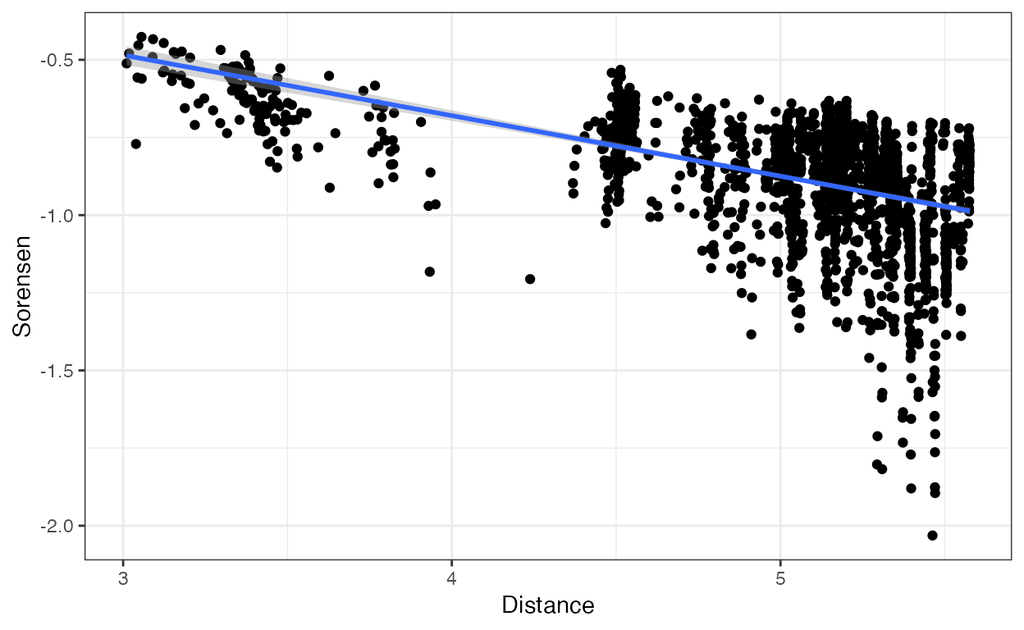

## 5.2 Variance of the product of two independent random variables

Let $X$ and $Y$ two random variables, here the estimators of $c$ and $A^z$.

The variance of their product $XY$ is

$$\begin{equation}
\begin{split}
\mathrm{Var}(XY) &= \mathbb{E}(X^2Y^2) -\mathbb{E}^2(XY) \\
&= \mathbb{E}(X^2)\mathbb{E}(Y^2) +\mathrm{Cov}(X^2,Y^2) \\
&\quad -[\mathbb{E}(X)\mathbb{E}(Y) +\mathrm{Cov}(X,Y)]^2.
\end{split}
\tag{4}
\end{equation}$$

If $X$ and $Y$ are independent (this applies to $c$ and $A^z$), covariances are 0 and the variance reduces to

$$\begin{equation}
\begin{split}
\mathrm{Var}(XY)&= \mathbb{E}(X^2)\mathbb{E}(Y^2) -[\mathbb{E}(X)\mathbb{E}(Y)]^2 \\
&= [\mathrm{Var}(X)+\mathbb{E}(X)^2][\mathrm{Var}(Y)+\mathbb{E}(Y)^2] \\
&\quad -[\mathbb{E}(X)E(Y)]^2 \\
&= \mathrm{Var}(X)\mathrm{Var}(Y) \\
&\quad +E(X)^2\mathrm{Var}(Y) +E(Y)^2\mathrm{Var}(X).
\end{split}
\tag{5}
\end{equation}$$

## 5.3 Non-parametric estimation of the number of species

Assuming that the plots are sample of a single community, the estimation of richness relies on the well-known non-parametric estimators. The observed number of species is 1314 among which 204 and 119 are sampled once and twice. The lower-bound estimation of the number of species by the Chao1 estimator is 1489. The best jackknife estimator (of order 3) is 1677.

An alternative, following Cazzolla Gatti *et al.* (2022), consists of paving the territory with a grid whose size does not change the estimation, say 100 km. In each 100 by 100 km cell of the grid, all available data is aggregated to obtain an occurrence dataset. The Chao2 estimator is finally applied: it combines the the number of species observed in only one or two cells to estimate the number of unobserved species. The estimation is 1643.

## 5.4 Log-series estimation of the number of species

Assuming that the plots are samples of a metacommunity that follows a log-series distribution, the rank-abundance curve can be extrapolated (figure 3) following ter Steege *et al.* (2013).

First, the total number of trees is estimated by extrapolation of the average number of trees per plot. There are close to 5 billion trees in French Guiana.

The probability for one of these trees to belong to a given species is obtained by averaging the frequency of the species among plots. Each plot is a sample of a local community whose composition is not completely known: for example, many rare species are not in the sample. The observed frequency of a species in a plot is not the probability of the species in the community: frequencies sum up to 1 while the sum of the actual probabilities of observed species, called the sample coverage (Good 1953), sums up to 1 minus that of the unobserved species. The actual probabilities of observed species can be estimated following Chao & Jost (2015), with the *entropart* package (Marcon & Hérault 2015).

The most abundant tree species is *Eperua falcata* with around 151 million trees.

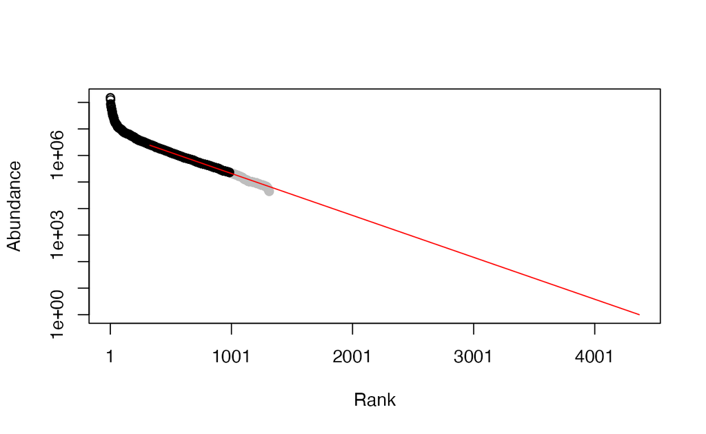

Figure 3: Extrapolation of the rank-abundance curve built from the GuyaDiv plots. Extrapolated abundances (in log scale) of observed species are plotted against the rank of their species. The abundances of unobserved species (the red curve) is extrapolated linearly from the center 50% of the distribution of the observed species. The rarest 25%, ignored for the extrapolation, are plotted as grey points.

The estimated number of species according to this model is 4368. This is undoubtedly a severe overestimation, see the discussion section of the paper.

## 5.5 Hyperdominance

Hyperdominance is a characteristic of many distributions of species. Figure 4 shows the accumulation of individuals from the most abundant to the rarest species.

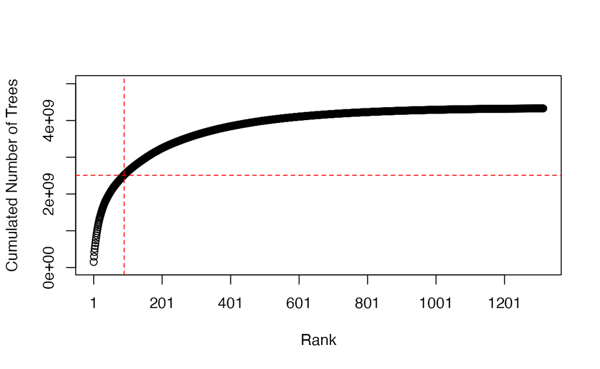

Figure 4: Accumulation of the number of individuals from the most abundant to the rarest species. The horizontal line corresponds to half the individuals. The vertical line allows reading the corresponding rank of the species.

Only 90 species, i.e. 4% of their estimated number, contain half the number of trees.

## 5.6 Universal species-area relationship

The method from Harte *et al.* (2009) is applied to our data. Assuming the number of individuals per area is constant and starting from a single initial inventory point (a number of species corresponding to a number of individuals), the number of species for twice the number of individuals can be calculated.

The number of trees per hectare is estimated from the Guyadiv network. To be consistent with the model, the geometric mean is applied: its logarithm equals the average logarithm of the number of trees in all 1-ha plots. We retain 602 trees/ha.

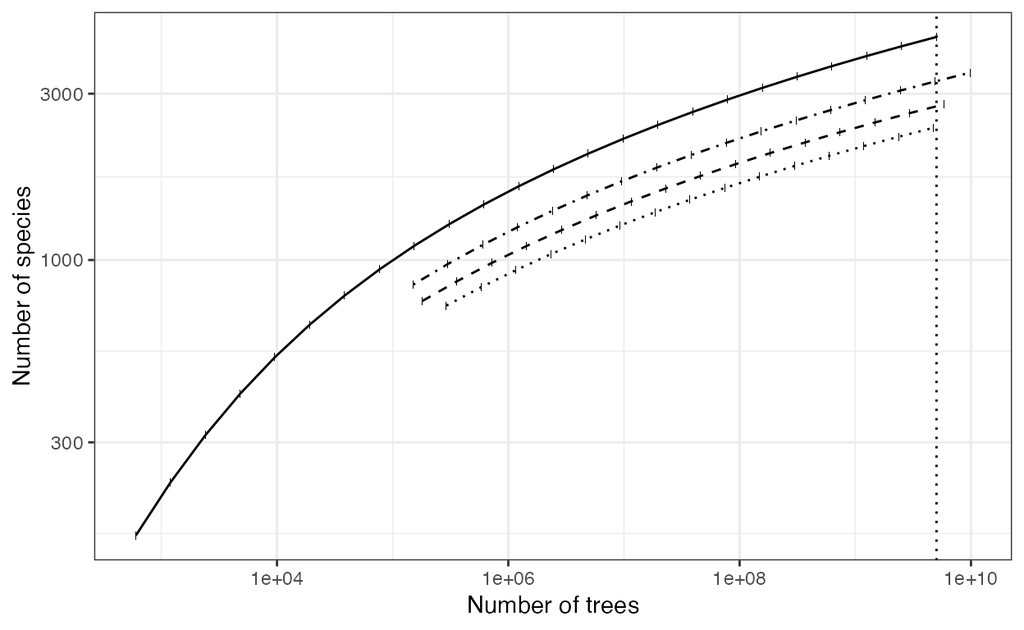

Figure 5: Extrapolation of the initial inventories up to 8 Mha (vertical line, assuming 602 trees/ha). The vertical line corresponds to the area of French Guiana. Curves are the estimated species-area curves from the Guyadiv 1-ha plots (solid line), Nouragues (dot-dashed line), Piste de Saint-Elie (dashed-line) and Paracou (dotted line) starting points. Estimated values are marked on the lines.

The extrapolation from 1 ha to 8 million hectares is clearly less reliable than that from the three large inventories, which are consistent with our main approach at the regional scale. The curves are almost perfectly fitted by a Michaelis-Menten model, estimated by the linear model (Lineweaver & Burk 1934) $\frac{1}{\log{S}} \sim \frac{1}{\log{n}}$, where $S$ is the number of species and $n$ the number of trees. The estimated number of species is then obtained for $n$ equal to 8 Mha times 602 trees per ha:

- From Nouragues: 3238 species.
- From Piste de Saint-Elie: 2739 species.
- From Paracou: 2385 species.

Arrhenius, O. (1921). [Species and area](https://doi.org/10.2307/2255763). *Journal of Ecology*, **9**(1), 95–99.

Béguinot, J. (2015). [Extrapolation of the species accumulation curve for incomplete species samplings: A new nonparametric approach to estimate the degree of sample completeness and decide when to stop sampling](https://doi.org/10.9734/ARRB/2015/22351). *Annual Research & Review in Biology*, **8**(5), 1–9.

Bonal, D., Bosc, A., Ponton, S., … Granier, A. (2008). [Impact of severe dry season on net ecosystem exchange in the Neotropical rainforest of French Guiana](https://doi.org/10.1111/j.1365-2486.2008.01610.x). *Global Change Biology*, **14**(8), 1917–1933.

Bongers, F., Charles-Dominique, P., Forget, P.-M., & Théry, M. (2001). *Nouragues: Dynamics and plant-animal interactions in a neotropical rainforest*, Vol. 80, Springer Science & Business Media.

Burnham, K. P., & Overton, W. S. (1978). [Estimation of the size of a closed population when capture probabilities vary among animals](https://doi.org/10.2307/2335915). *Biometrika*, **65**(3), 625–633.

Cazzolla Gatti, R., Reich, P. B., Gamarra, J. G. P., … Liang, J. (2022). [The number of tree species on Earth](https://doi.org/10.1073/pnas.2115329119). *Proceedings of the National Academy of Sciences*, **119**(6), e2115329119.

Chao, A. (1987). [Estimating the population size for capture-recapture data with unequal catchability](https://doi.org/10.2307/2531532). *Biometrics*, **43**(4), 783–791.

Chao, A. (2004). Species richness estimation. In N. Balakrishnan, C. B. Read, & B. Vidakovic, eds., *Encyclopedia of statistical sciences*, 2nd ed., New York: Wiley.

Chao, A., & Jost, L. (2015). [Estimating diversity and entropy profiles via discovery rates of new species](https://doi.org/10.1111/2041-210X.12349). *Methods in Ecology and Evolution*, **6**(8), 873–882.

Engel, J. (2015). Plot networks & teams. *ATDN tree morphospecies website*, http://atdnmorphospecies.myspecies.info/node/781.

Gárcia Martín, H., & Goldenfeld, N. (2006). [On the origin and robustness of power-law species-area relationships in ecology](https://doi.org/10.1073/pnas.0510605103). *Proceedings of the National Academy of Sciences of the United States of America*, **103**(27), 10310–10315.

Gonzalez, S., Bilot-Guérin, V., Delprete, P. G., … et al.,. (2022). L’herbier IRD de Guyane, https://herbier-guyane.ird.fr/.

Good, I. J. (1953). [The population frequency of species and the estimation of population parameters](https://doi.org/10.1093/biomet/40.3-4.237). *Biometrika*, **40**(3/4), 237–264.

Gotelli, N. J., & Colwell, R. K. (2001). [Quantifying biodiversity: Procedures and pitfalls in the measurement and comparison of species richness](https://doi.org/10.1046/j.1461-0248.2001.00230.x). *Ecology Letters*, **4**(4), 379–391.

Gourlet-Fleury, S., Guehl, J. M., & Laroussinie, O. (2004). *Ecology & management of a neotropical rainforest. Lessons drawn from Paracou, a long-term experimental research site in French Guiana*, Paris: Elsevier.

Grilli, J., Azaele, S., Banavar, J. R., & Maritan, A. (2012). [Spatial aggregation and the speciesarea relationship across scales](https://doi.org/10.1016/j.jtbi.2012.07.030). *Journal of Theoretical Biology*, **313**(0), 87–97.

Guitet, S., Pélissier, R., Brunaux, O., Jaouen, G., & Sabatier, D. (2015). [Geomorphological landscape features explain floristic patterns in French Guiana rainforest](https://doi.org/10.1007/s10531-014-0854-8). *Biodiversity and Conservation*, **24**(5), 1215–1237.

Harte, J., Kinzig, A., & Green, J. (1999a). [Self-similarity in the distribution and abundance of species](https://doi.org/10.1126/science.284.5412.334). *Science*, **284**(5412), 334–336.

Harte, J., Mccarthy, S., Taylor, K., Kinzig, A., & Fischer, M. L. (1999b). [Estimating species-area relationships from scale plot to landscape data using species spatial-turnover](https://doi.org/10.2307/3546568). *Oikos*, **86**(1), 45–54.

Harte, J., Smith, A. B., & Storch, D. (2009). [Biodiversity scales from plots to biomes with a universal species-area curve](https://doi.org/10.1111/j.1461-0248.2009.01328.x). *Ecology Letters*, **12**(8), 789–797.

Harte, J., Zillio, T., Conlisk, E., & Smith, A. B. (2008). [Maximum entropy and the state-variable approach to macroecology](https://doi.org/10.1890/07-1369.1). *Ecology*, **89**(10), 2700–2711.

Hubbell, S. P. (2001). *The unified neutral theory of biodiversity and biogeography*, Princeton University Press.

Krishnamani, R., Kumar, A., & Harte, J. (2004). [Estimating species richness at large spatial scales using data from small discrete plots](https://doi.org/10.1111/j.0906-7590.2004.03790.x). *Ecography*, **27**(5), 637–642.

Lineweaver, H., & Burk, D. (1934). [The determination of enzyme dissociation constants](https://doi.org/10.1021/ja01318a036). *Journal of the American Chemical Society*, **56**(3), 658–666.

MacArthur, R. H., & Wilson, E. O. (1967). The theory of island biogeography. In *Monographs in population biology*, Vol. 1, Princeton University Press.

Marcon, E., & Hérault, B. (2015). [Entropart, an R package to measure and partition diversity](https://doi.org/10.18637/jss.v067.i08). *Journal of Statistical Software*, **67**(8), 1–26.

Mirabel, A., Hérault, B., & Marcon, E. (2020). [Diverging taxonomic and functional trajectories following disturbance in a Neotropical forest](https://doi.org/10.1016/J.SCITOTENV.2020.137397). *Science of The Total Environment*, **720**, 137397.

Mirabel, A., Marcon, E., & Hérault, B. (2021). [30 Years of postdisturbance recruitment in a Neotropical forest](https://doi.org/10.1002/ece3.7634). *Ecology and Evolution*, **11**(21), 14448–14458.

Molino, J.-F., & Sabatier, D. (2001). [Tree diversity in tropical rain forests: A validation of the intermediate disturbance hypothesis](https://doi.org/10.1126/science.1060284). *Science*, **294**(5547), 1702–1704.

Molino, J.-F., Sabatier, D., Engel, J., … Martin, C.A. (2022). An annotated checklist of the tree species of French Guiana, including a vernacular nomenclature. *Adansonia*, **submitted**.

Preston, F. W. (1962). [The canonical distribution of commonness and rarity: Part I](https://doi.org/10.2307/1931976). *Ecology*, **43**(2), 185–215.

R Core Team. (2022). *R: A language and environment for statistical computing*, Vienna, Austria: R Foundation for Statistical Computing.

Shen, T.-J., Chao, A., & Lin, C.-F. (2003). Predicting the number of new species in a further taxonomic sampling. *Ecology*, **84**(3), 798–804.

Slik, J. W. F., Arroyo-Rodríguez, V., Aiba, S.-I., … Venticinque, E. M. (2015). [An estimate of the number of tropical tree species](https://doi.org/10.1073/pnas.1423147112). *Proceedings of the National Academy of Sciences of the United States of America*, **112**(24), 7472–7477.

Sørensen, T. (1948). A method of establishing groups of equal amplitude in plant sociology based on similarity of species content and its application to analyses of the vegetation on danish commons. *Biologiske Skrifter*, **5**(4), 1–34.

ter Steege, H., Pitman, N. C. A., Sabatier, D., … Silman, M. R. (2013). [Hyperdominance in the amazonian tree flora](https://doi.org/10.1126/science.1243092). *Science*, **342**(6156), 1243092.

ter Steege, H., Prado, P. I., Lima, R. A. F. de, … Pickavance, G. (2020). [Biased-corrected richness estimates for the Amazonian tree flora](https://doi.org/10.1038/s41598-020-66686-3). *Scientific Reports*, **10**(1), 10130.

Triantis, K. A., Guilhaumon, F., & Whittaker, R. J. (2012). [The island speciesarea relationship: Biology and statistics](https://doi.org/10.1111/j.1365-2699.2011.02652.x). *Journal of Biogeography*, **39**(2), 215–231.

Volkov, I., Banavar, J. R., Hubbell, S. P., & Maritan, A. (2003). [Neutral theory and relative species abundance in ecology](https://doi.org/10.1038/nature01883). *Nature*, **424**(6952), 1035–1037.

Williamson, M., Gaston, K. J., & Lonsdale, W. M. (2001). [The speciesarea relationship does not have an asymptote!](https://doi.org/10.1046/j.1365-2699.2001.00603.x) *Journal of Biogeography*, **28**(7), 827–830.

Xu, H., Liu, S., Li, Y., Zang, R., & He, F. (2012). [Assessing non-parametric and area-based methods for estimating regional species richness](https://doi.org/10.1111/j.1654-1103.2012.01423.x). *Journal of Vegetation Science*, **23**(6), 1006–1012.